### 13016370 Computer Vision

# Deep Learning in Computer Vision: A Very Breif Introduction

###### by Ukrit Watchareeruetai, Software Engineering Program, International College, KMITL

###### Draft: November 12, 2018

- **Objective:** To explain the concept of deep learning and how it is applied to computer vision
- **Contents:**
  - Pattern recognition, machine learning, and deep learning
  - Building and training neural networks using Keras package
    - Loading a dataset
    - Building a simple feedforward neural network
    - Building a convolutional neural network
  - Case study: Pokemon classification

## Pattern recognition

- An approach of computer vision to perform image/object recognition is based on the concept of **pattern recognition**.
- This approach can be divided into two main steps:
  - **Feature extraction**
    - Measure some distinct characteristics of those objects
    - Convert those characteristics into numerical values
    - These measured characteristics are called **features**.
    - Several features of an object can be grouped into one vector, a.k.a., **feature vector**.
    - **Preprocessing** might be required to convert an input into a more proper form.
      - Point-processing, local processing
      - Frequency-domain method
      - Image reconstruction/enhancement
      - Image segmentation
  - **Classification**
    - Create some rules for distinguishing one type of objects from another based upon its feature vector.
    - A mathematical model incorporating these rules is referred to as a **classifier**.

## Example: Cat and dog recognition

- Features:
  - Feature 1 ($f_1$): body length
  - Feature 2 ($f_2$): skull length

[figure not shown]

Images from the Internet: These Photos by Unknown Author is licensed under CC BY-SA

## Feature spcae

- A space of features used to represent objects
  - In this case, it is a space of two features:
    - Body length
    - Skull length
  - In practical, $n$-dimensional of feature spcae is considered.
    - $n$ is the number of features.

[figure not shown]

Images from the Internet: These Photos by Unknown Author is licensed under CC BY-SA

## Classification rule

- A rule used to classify each instance into a class based upon the features
  - Three examples of linear decision rule

[figure not shown]

## Classification rule

- Using only **one instance** (a.k.a., **data sample**) from each class cannot create a robust rule:
- Need more data instances!

[figure not shown]

Images from the Internet: These Photos by Unknown Author is licensed under CC BY-SA

## Classification rule

- The previous classification rules do not work perfectly any more.
- Cannot correctly classify some instances
- A set of data instances used in the process of classification construction is called a **training dataset**.
- The process of constructing a classifier is known as **training** or **learning**.
- To assess the performance of a learned model, another set of data, known as a **test set**, hould be used.
  - This test set is used to evaluate the **generalization performance** of the model.
    - How well the model can be applied to predict/classify unseen patterns

[figure not shown]

## Linear classifier

- A new rule can be created.
  - This classification rule is **linear**.
  - A classifier obeying this linear classification rule is called a **linear classifier**.
  - Its decision boundary can be represented in the form:
    - $c_0 + c_1f_1 + c_2f_2 + … + c_nf_n = 0$
    - Let $n$ denote the number of features
    - **Parameters** $c_i$ control the shape of decision rule.
  - However, in practical, the distributions of objects in the feature space are usually not **linearly separable**.
    - Linearly separable problem means it can be solved perfectly using a linear classifier.
      - Can be perfectly classify by a linear decision rule
      - 2D cases: A straight line
      - 3D cases: A flat surface known as a plane
      - 4D or higher cases: A hyperplane

[figure not shown]

## Non-linear classifier

- A **non-linear classifier** classifies data using a more complicated rule than a hyperplane decision rule.
  - Construct a non-linear decision rule
- The term **capacity** relates to the complexity of the model that can be created.
  - High capacity -> complex model
  - Low capacity -> simple model
- A classifier model with too high capacity tends to **overfit** to the training dataset.
  - A classifier is said to be overfit if it can successfully classify a training dataset but not fails to do so for an unknown test set.
  - It cannot capture the true nature of the problem.
    - It learns something irrelevant to the problem but coincidentally presented in most instances in the training set.

[figure not shown]

## Machine learning

- **Machine learning** is a field of AI studying how to make a computer learns some rules for solving a problem from given data.
- It can be used to adjust the parameters of a classifier or decision rule based upon a given training dataset.
  - Let the computer learn the rules themselve
  - Require less human intervention
    - For a very complex problem, human might not be able to construct a set of rules effectively.
    - Machine can do it better!

## Artificial neural network

- **Artificial neural network (ANN)** or in short **neural network (NN)** is a classfication model inspired by biological neurons in the brain.
  - Usually consist of two or more layers of neurons
  - Three fundamental types of layer:
    - **Input layer**
      - Directly connect to the input of the network
      - The number of neurons in this layer equals to the number of features.
    - **Output layer**
      - The output of the network
      - For classification problems, the number of output neurons equals to the number of classes.
    - **Hidden layer**
      - Layers between the input and output layers
      - Transform input features into a more complicated form
  - The following figure is an example of a **fully-connected**, **feedforward** neural network.
    - *Fully-connected* means each neuron in a layer is connected to each neuron in the adjacent layer(s).
    - *Feedforward* means there is no backward connection. The data is feeded-forward from the input layer, through the hidden layer, to the output layer.

[figure not shown]

## How neural networks work?

- Each neuron has some connections to other neurons, usually in the adjacent layers.
- There is a numerical value called **weight** associated to each connection in the network.
- The weight determines the importance of each connection.
  - Higher weight -> more important
  - Smaller weight -> less important
- Each neurons in the hidden layer recieves inputs from the previous layer.
- Then perform a calcuation as follows:

  \begin{equation} h_i = g(w_{i1}x_1 + w_{i2}x_2 + \cdots + w_{iD}x_D + b_i) \end{equation}
  - $g(\cdot)$ is an **activation function**.
    - Introduce non-linearity to the network
  - $w_{ij}$ represents the weight of the connection between the node $j$ and the input $i$.
  - $b_i$ is known as **bias**.
    - A numerical value associated to each hidden neuron (and output neurons in some models)
  - Both wegiths and bias are parameters of the model that need to be adjusted by a **training/learning algorithm**.
- The output of a hidden neuron is sent to all connected neurons in the next layers.

[figure not shown]

## How to train neural networks?

- A traditional learning algorithm for neural networks is called **gradient based learing**.
  - A sample or batch of training data is feeded through the network to produce the output.
  - The output is then compared with a known answer, called **target** or **label**.
  - By using the target, it can be judged if the output is correct or wrong.
  - If the output is correct, just do nothing.
  - If the output is wrong, the **error** or **loss** will be used to adjust the weights and biases of the network.
    - The error is a function of parameters, i.e., weights and biases.
    - The error is differentiated with respect to each weight and each bias.
      - The result of the differentation is known as the **gradient vector**.
    - To minimize the error, the weights and biases will be adjusted in the direction of opposite to the gradient vector.
    - This technique is known as **gradient descent**.

## Deep learning

- **Deep learning** is a subfield of machine learning aiming to study about **deep neural networks** and their training/learning algorithms.
  - A deep neural network refers to a neural network consisting of many layers.
    - In the past, a network with 4-6 layers was considered *deep*.
    - Presently, neural networks may consist of more than 100 layers.
- A deep neural network can automatically build more complicated, useful features from layer-to-layer.
  - It has been shown in many papers that **feature engineering** is not required.
  - **Hand-crafted features** become no longer significant.
  - A deep neural network can be trained directly from raw data.
- However, a deep neural network needs to be tuned carefully and trained with some well-designed technqiues.
  - In the past, deep neural networks could not gain popularity from researchers because there were no effective learning algorihtms.
    - A well-known problem in training a deep neural network is known as **gradient vanishing problem**.
  - So far, several techniques that enable learning deep neural networks have been proposed.
    - Pretraining
    - Dropout
    - Regularization
    - Weight sharing
- Another drawback of deep learning is that it usually requires a huge amount of training data.
  - Inadequate amount of training data leads to overfitting problem.

## Building and training neural networks using Keras

- Keras is a high-level deep learning library written in Python
- Built on top on other libraries:
  - TensorFlow
  - Theano
  - CNTK
- Allow for easy prototyping and fast experimentation
- Installation
  - `pip install keras`

## Loading dataset using Keras

- Keras provides a module for loading various benchmark computer vision datasets:
  - MNIST:
    - 28 $\times$ 28 grayscale images (784 features)
    - 10 classes of handwritten digit (0-9)
    - 60,000 training samples
    - 10,000 test samples
    - http://yann.lecun.com/exdb/mnist/
  - Fasion-MNIST:
    - Same as MNIST but different problem-domain
    - 10 classes of fashion images
      - T-shirt/top, trouser, pullover, dress, coat, sandal, shirt, sneaker, bag, and ankle boot
    - https://www.kaggle.com/zalando-research/fashionmnist/home
  - CIFAR-10:
    - 32 $\times$ 32 color images (3 $\times$ 32 $\times$ 32 = 3,072 features)
    - 10 classes
      - Airplanes, cars, birds, cats, deer, dogs, frogs, horses, ships, and trucks
    - 50,000 training samples
    - 10,000 test samples
    - https://www.cs.toronto.edu/~kriz/cifar.html
  - CIFAR-100:
    - Same as CIFAR-10 but have more categories
    - 100 classes grouped into 20 superclasses
    - https://www.cs.toronto.edu/~kriz/cifar.html

```python
from keras.datasets import mnist, fashion_mnist, cifar10, cifar100

(X_train, y_train), (X_test, y_test) = mnist.load_data()
#(X_train, y_train), (X_test, y_test) = fashion_mnist.load_data()
#(X_train, y_train), (X_test, y_test) = cifar10.load_data()
#(X_train, y_train), (X_test, y_test) = cifar100.load_data(label_mode='fine')

print(X_train.shape)
print(y_train.shape)
print(X_test.shape)
print(y_test.shape)
```

```
(60000, 28, 28)
(60000,)
(10000, 28, 28)
(10000,)
```

```python
X_train = X_train.reshape(60000, 784).astype('float32')
X_test = X_test.reshape(10000, 784).astype('float32')
```

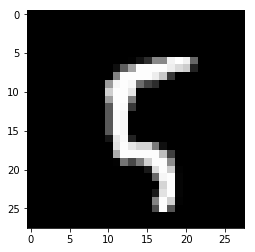

```python
import matplotlib.pyplot as plt

plt.figure()
plt.imshow(X_train[100,:].reshape((28,28)), cmap='gray')
plt.show()
```

```python
print(y_train[100])
```

```
5
```

## One-hot encoding

- One-hot encoding (OHE) is often used as a target vector for neural networks.
- The size of the vector equals the number of classes.
- All elements are 0 except the element corresponding to the label, which is 1.
- Each element is the target of each neuron in the output layer.
- For examples:
  - $[1 \ 0 \ 0 \ 0 \ 0 \ 0 \ 0 \ 0 \ 0 \ 0]$ = class 0
  - $[0 \ 1 \ 0 \ 0 \ 0 \ 0 \ 0 \ 0 \ 0 \ 0]$ = class 1
  - $[0 \ 0 \ 1 \ 0 \ 0 \ 0 \ 0 \ 0 \ 0 \ 0]$ = class 2
  - $[0 \ 0 \ 0 \ 0 \ 0 \ 0 \ 0 \ 0 \ 0 \ 1]$ = class 9

```python
from keras.utils import np_utils

Y_train = np_utils.to_categorical(y_train)
Y_test = np_utils.to_categorical(y_test)

print(y_train[100])
print(Y_train[100])
```

```
5
[0. 0. 0. 0. 0. 1. 0. 0. 0. 0.]
```

```python
print(X_train.shape)
print(Y_train.shape)
print(X_test.shape)
print(Y_test.shape)
```

```
(60000, 784)
(60000, 10)
(10000, 784)
(10000, 10)
```

## Building a simple model

- A sequential model
  - Create a feed-forward neural networks
    - No backward connections allowed
    - Just stack layers on top of another
- Example: creating a feed-forward NN with the following specfications:
  - Input: 784 nodes
  - No hidden layer
  - No activation
  - Output: 10 nodes

```python
from keras.models import Sequential
from keras.layers import Dense

model = Sequential()
model.add(Dense(10, input_shape=(784,)))
```

## Checking the model

- Before executing the model, it is worth to check its structure
- Can be done using method: `model.summary()`
- Describe each layer in the model, shape of output, and the number of weights (parameters)
  - Bias is included in a Dense layer automatically by adding an extra constant input (its value is 1).
  - There is a connection between this constant input to each node in the Dense layer.
  - The value associated to the connection is the bias.

```python
model.summary()
```

```
_________________________________________________________________
Layer (type)                 Output Shape              Param #
=================================================================
dense_1 (Dense)              (None, 10)                7850
=================================================================
Total params: 7,850
Trainable params: 7,850
Non-trainable params: 0
_________________________________________________________________
```

## Compile and fit the model

- The model needs to be trained before it can be used.
- Specify loss function and learning algorithm by `model.complie()`
  - Loss function
    - Mean squared error (`loss='mean_squared_error'`) \begin{equation} MSE = \frac{1}{S} \sum_{s=1}^{S} \Vert \mathbf{t}_s - \mathbf{o}_s \Vert_2^2 \end{equation}
      - $S$ is the total number of samples used to calculate the loss
      - $\mathbf{o}_s$ is the output produced by the network given the $s$-th input sample
      - $\mathbf{t}_s$ is the target of the $s$-th input sample
    - Mean absolute error (`loss='mean_absolute_error'`) \begin{equation} MAE = \frac{1}{S} \sum_{s=1}^{S} \vert \mathbf{t}_s - \mathbf{o}_s \vert \end{equation}
    - Categoriacal cross-entropy (`loss='categorical_crossentropy'`) \begin{equation} CCE = -\frac{1}{S} \sum_{s=1}^{S} \sum_{c=1}^{C} \mathbf{t}_s \cdot log(\mathbf{p}_s) \\ \mathbf{p}_s = softmax(\mathbf{o}_s) \end{equation}
  - Optimization algorithm
    - Stochastic gradient descent (SGD)
    - RMSprop
    - Adam
    - Adagrad
    - AdaMax
  - Metrics
    - Accuracy
      - The ratio between the number of correctly classified samples and the total number of samples
- Train the model using `model.fit()`
  - Training samples
  - Corresponding labels
  - Batch size
  - Number of epochs
  - Ratio of validation set
  - Progress message

```python
from keras.optimizers import SGD

model.compile(loss='categorical_crossentropy', optimizer=SGD(), metrics=['accuracy'])
history = model.fit(X_train, Y_train, batch_size=200, epochs=100, verbose=1, validation_split=0.2)
```

```
Train on 48000 samples, validate on 12000 samples
```

## Evaluate the trained model

- Use method `model.evaluate()`
- Pass an unseen dataset to evaluate the generalization performance

```python
score = model.evaluate(X_test, Y_test, verbose=1)
print('Test score:', score[0])
print('Test accuracy:', score[1])
```

```
Test score: 10.133972030639649
Test accuracy: 0.1548
```

## Try again

- Normalize input data
- Add a hidden layer with an activation function
- Use softmax activation function at the output node
- Change optimization algorithm
- Measure training time

## Activation function

- Add non-linearity into the network
- Apply to a linear combination of its input
- Various type of activation:
  - Logistic sigmoid (`sigmoid`):

    \begin{equation} g(x) = \frac{1}{1+e^{-x}} \end{equation}
  - Hyperpolic tangent (`tanh`):

    \begin{equation} g(x) = tanh{x} = \frac{e^x - e^{-x}}{e^x - e^{-x}} \end{equation}
  - Rectified linear unit (`relu`):

    \begin{equation} g(x) = max(0,x) \end{equation}
  - Softmax (`softmax`):

    \begin{equation} g(\mathbf{x})=\frac{e^{x_i}}{\sum_{j=1}^{D}} \end{equation}
    - $D$ is the dimension of the vector $\mathbf{x}$
    - Usually, used with the output layer of a network to convert output to be probility value

```python
#import necessary modules
from keras.datasets import mnist, fashion_mnist, cifar10, cifar100
from keras.utils import np_utils
from keras.models import Sequential
from keras.layers import Dense, Activation
from keras.optimizers import SGD, RMSprop, Adam
import time

#network structure
INPUT_DIM = 784
NUM_HIDDEN = 1000
NUM_CLASS = 10

#loading dataset
(X_train, y_train), (X_test, y_test) = mnist.load_data()
X_train = X_train.reshape(60000, INPUT_DIM).astype('float32')
X_test = X_test.reshape(10000, INPUT_DIM).astype('float32')
X_train /= 255
X_test /= 255
Y_train = np_utils.to_categorical(y_train)
Y_test = np_utils.to_categorical(y_test)

#building a model
model = Sequential()
model.add(Dense(NUM_HIDDEN, input_shape=(INPUT_DIM,)))
model.add(Activation('sigmoid'))
model.add(Dense(NUM_CLASS))
model.add(Activation('softmax'))
model.summary()

#train the model
start_time = time.time()
model.compile(loss='categorical_crossentropy', optimizer=Adam(), metrics=['accuracy'])
history = model.fit(X_train, Y_train, batch_size=200, epochs=100, verbose=1, validation_split=0.2)
print("Time = ", time.time() - start_time)

#evaluate the model
score = model.evaluate(X_test, Y_test, verbose=1)
print('Test score:', score[0])
print('Test accuracy:', score[1])
```

```
_________________________________________________________________
Layer (type)                 Output Shape              Param #
=================================================================
dense_2 (Dense)              (None, 1000)              785000
_________________________________________________________________
activation_1 (Activation)    (None, 1000)              0
_________________________________________________________________
dense_3 (Dense)              (None, 10)                10010
_________________________________________________________________
activation_2 (Activation)    (None, 10)                0
=================================================================
Total params: 795,010
Trainable params: 795,010
Non-trainable params: 0
_________________________________________________________________
Train on 48000 samples, validate on 12000 samples
Time =  276.15770292282104
Test score: 0.09786079965312129
Test accuracy: 0.9822
```

## Analyze training performance

- Plot accuracy and loss against epochs
- Use a package named `matplotlib`
  - Support various types of graph
  - https://matplotlib.org/

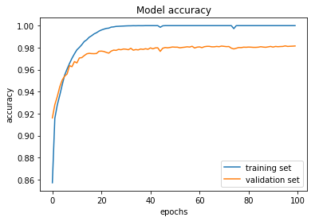

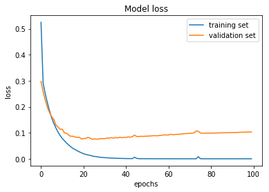

```python
import matplotlib.pyplot as plt

plt.figure()
plt.plot(history.history['acc'])
plt.plot(history.history['val_acc'])
plt.title('Model accuracy')
plt.xlabel('epochs')
plt.ylabel('accuracy')
plt.legend(['training set', 'validation set'], loc='lower right')
plt.show()

plt.figure()
plt.plot(history.history['loss'])
plt.plot(history.history['val_loss'])
plt.title('Model loss')
plt.xlabel('epochs')
plt.ylabel('loss')
plt.legend(['training set', 'validation set'], loc='upper right')
plt.show()
```

## Dropout

- Dropout is a technique used to regularize deep neural networks.
  - Regularization means any modification aiming at improving the generalization performance, i.e,. test accuracy. -Training accuracy may or may not be improved.
- Dropout randomly *drops* (or tempolarity removes) some neurons from the calculation.
  - The remaining neurons are forced to learn some useful features on their own.
    - This can avoid the case that the network is being dominated by some neurons.
  - A paramater controlling the number of neurons that will be dropped is known as *drop rate*.
- Ref. N. Srivastava, G. Hinton, A. Krizhevsky, I. Sutskever, and R. Salakhutdinov, "Dropout: A simple way to prevent neural networks from overfitting," Journal of Machine Learning Research, vol.15, pp.1929--1958, 2014.

```python
from keras.layers import Dropout

#building a model
model = Sequential()
model.add(Dense(NUM_HIDDEN, input_shape=(INPUT_DIM,)))
model.add(Activation('sigmoid'))
model.add(Dropout(0.5))
model.add(Dense(NUM_CLASS))
model.add(Activation('softmax'))
model.summary()

#train the model
start_time = time.time()
model.compile(loss='categorical_crossentropy', optimizer=Adam(), metrics=['accuracy'])
history = model.fit(X_train, Y_train, batch_size=200, epochs=100, verbose=1, validation_split=0.2)
print("Time = ", time.time() - start_time)

#evaluate the model
score = model.evaluate(X_test, Y_test, verbose=1)
print('Test score:', score[0])
print('Test accuracy:', score[1])
```

```
_________________________________________________________________
Layer (type)                 Output Shape              Param #
=================================================================
dense_4 (Dense)              (None, 1000)              785000
_________________________________________________________________
activation_3 (Activation)    (None, 1000)              0
_________________________________________________________________
dropout_1 (Dropout)          (None, 1000)              0
_________________________________________________________________
dense_5 (Dense)              (None, 10)                10010
_________________________________________________________________
activation_4 (Activation)    (None, 10)                0
=================================================================
Total params: 795,010
Trainable params: 795,010
Non-trainable params: 0
_________________________________________________________________
Train on 48000 samples, validate on 12000 samples
Time =  288.70132327079773
Test score: 0.08589731342030155
Test accuracy: 0.9832
```

## Convolutional neural network

- A **convolutional neural network (CNN)** is a class of feed-forward neural networks mostly applied to solve computer vision problems.
- A CNN usually consists of various types of layers:
  - Convolutional layer
  - Pooling layer
  - Fully-connected layer
- Convolutional layers make CNNs distinct from other classes of neural networks.
  - Use the concept of weight-sharing.

[figure not shown]

Image from: https://en.wikipedia.org

## Convolution layers

- A convolution layer contains a number of filters, which are applied to an input of the layer by using convolution.
  - Input: a $C$-channel image (volume) of size $M \times N$
  - Output: a $X$-channel image of size $M \times N$ (or smaller)
    - $X$ is the number of filters in the convolution layer
    - One filter produces one channel in the output image.
    - Each filter usually has single channel.
- Each filter is adjusted during training to extract a local feature useful for the problem at hand.
  - Require no hand-crafted features
  - But automatically learn useful features from data
- Usually, a convolution layer in the beginning of the network extracts low-level features.
- A subsequent convolution layer can extract relatively more complicated features.